# Homework 08

The former kernel-tuning question has moved to Homework 09.

Solutions for Questions 1 and 2 will be available after Monday, October 19, 2026. No solution can be provided for Question 3.

For Questions 1 and 2, use either R or Python.

## Question 1: Boundary and margin

Use `margin-geometry-20.csv` from the combined ZIP, which contains 20 observations with predictors $x_1,x_2$ and class labels $y\in\{-1,1\}$. Consider the score

$$f(x)=0.8x_1+0.6x_2.$$

Since $\|(0.8,0.6)\|_2=1$, the lines $f(x)=\pm1$ are each a distance 1 from the decision boundary $f(x)=0$.

1. Calculate the distance from every observation to the decision boundary and its functional margin $yf(x)$. In a table, report these values and whether each observation is inside, on, or beyond the margin for its class. Compare $yf(x)$ with 1 to make this distinction.
2. Plot the observations, the boundary $f(x)=0$, and the margin lines $f(x)=\pm1$. Distinguish the two classes and identify the observations inside the margin in your plot.
3. Report how many observations are inside, on, and beyond the margin. Which observations are misclassified by this decision rule?

Use the observation numbers supplied in the data. Set the $x_1$ axis to $[-3.2,3.2]$, set the $x_2$ axis to $[-3,3]$, and use an equal aspect ratio. Do not fit a new classifier for this question.

## Question 2: Margin in four dimensions

Use `margin-geometry-4d.csv` from the combined ZIP, which contains 50 observations with four predictors and class labels $y\in\{-1,1\}$. Consider the linear score

$$f(\mathbf{x})=\beta_0+\mathbf{x}^{\mathsf T}\boldsymbol{\beta},
\qquad
\beta_0=-1,
\quad
\boldsymbol{\beta}=(1,2,-2,4)^{\mathsf T}.$$

1. Project the observations onto the direction of $\boldsymbol{\beta}$ and plot their positions on one axis. Distinguish the two classes and mark the decision boundary. Use the plot to calculate the geometric margin $M$, the distance from the boundary to the closest observation.
2. Express the same decision boundary using the SVM normalization in which the smallest functional margin $y_i f(\mathbf{x}_i)$ is set to 1. What are the corresponding values of $\boldsymbol{\beta}$ and $\beta_0$?

## Worked solution for Question 1

Let

$$f(x)=0.8x_1+0.6x_2.$$

The boundary is $f(x)=0$, and the margin lines are $f(x)=\pm 1$.

```r
d1 <- read.csv("data/margin-geometry-20.csv")
d1$f <- 0.8 * d1$x1 + 0.6 * d1$x2
d1$distance_to_boundary <- abs(d1$f)
d1$yf <- d1$y * d1$f
d1$status <- ifelse(d1$yf < 1, "inside",
                    ifelse(d1$yf > 1, "beyond", "on"))
out1 <- d1[order(d1$observation),
           c("observation", "x1", "x2", "y", "f",
             "distance_to_boundary", "yf", "status")]
out1
```

```
   observation    x1    x2  y     f distance_to_boundary    yf status
1            1  0.68  0.76  1  1.00                 1.00  1.00     on
2            2  1.80 -0.15  1  1.35                 1.35  1.35 beyond
3            3  1.38  0.66  1  1.50                 1.50  1.50 beyond
4            4  0.88  1.66  1  1.70                 1.70  1.70 beyond
5            5  0.62  2.34  1  1.90                 1.90  1.90 beyond
6            6  2.78 -0.04  1  2.20                 2.20  2.20 beyond
7            7  1.86  1.52  1  2.40                 2.40  2.40 beyond
8            8  0.50  0.40  1  0.64                 0.64  0.64 inside
9            9  0.10  0.20  1  0.20                 0.20  0.20 inside
10          10 -0.40  0.20  1 -0.20                 0.20 -0.20 inside
11          11 -0.92 -0.44 -1 -1.00                 1.00  1.00     on
12          12 -0.50 -1.50 -1 -1.30                 1.30  1.30 beyond
13          13 -1.90 -0.05 -1 -1.55                 1.55  1.55 beyond
14          14 -0.44 -2.33 -1 -1.75                 1.75  1.75 beyond
15          15 -1.98 -0.61 -1 -1.95                 1.95  1.95 beyond
16          16 -2.74  0.07 -1 -2.15                 2.15  2.15 beyond
17          17 -1.90 -1.55 -1 -2.45                 2.45  2.45 beyond
18          18 -0.50 -0.40 -1 -0.64                 0.64  0.64 inside
19          19  0.00 -0.40 -1 -0.24                 0.24  0.24 inside
20          20  0.40 -0.20 -1  0.20                 0.20 -0.20 inside
```

Interpretation: an observation is inside the margin if $y_if(x_i)<1$, on the margin if $y_if(x_i)=1$, and beyond the margin if $y_if(x_i)>1$.

```r
table(d1$status)
```

```
beyond inside     on
    12      6      2
```

This gives 6 points inside the margin, 2 on the margin, and 12 beyond the margin. The misclassified observations are those with negative functional margin:

```r
d1$observation[d1$yf < 0]
```

```
[1] 10 20
```

So the classifier misclassifies observations 10 and 20.

A plot of the observations and the margin lines is:

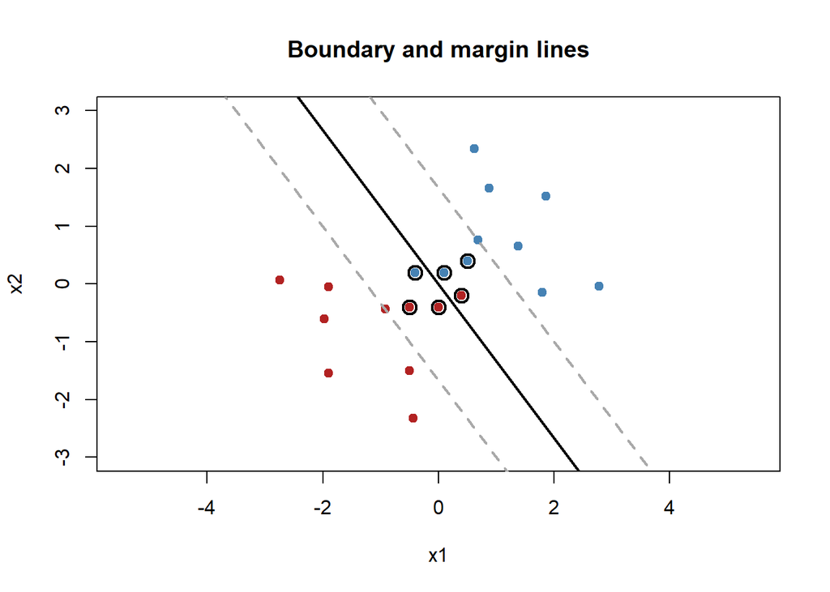

```r
plot(d1$x1, d1$x2,
     pch = 19,
     col = ifelse(d1$y == 1, "steelblue", "firebrick"),
     xlim = c(-3.2, 3.2),
     ylim = c(-3, 3),
     asp = 1,
     xlab = "x1",
     ylab = "x2",
     main = "Boundary and margin lines")

abline(a = 0, b = -0.8/0.6, lwd = 2, col = "black")
abline(a = 1/0.6, b = -0.8/0.6, lwd = 2, lty = 2, col = "darkgray")
abline(a = -1/0.6, b = -0.8/0.6, lwd = 2, lty = 2, col = "darkgray")
inside_idx <- d1$status == "inside"
points(d1$x1[inside_idx], d1$x2[inside_idx],
       pch = 1, cex = 1.6, lwd = 2, col = "black")
```

## Worked solution for Question 2

For the four-dimensional problem,

$$f(x)=\beta_0 + x^\top\beta,
\qquad
\beta_0=-1,
\quad
\beta=(1,2,-2,4)^\top.$$

The projection onto the direction of $\beta$ is

$$\frac{x^\top\beta}{\|\beta\|_2}.$$

```r
d2 <- read.csv("data/margin-geometry-4d.csv")
X <- as.matrix(d2[, c("x1", "x2", "x3", "x4")])
beta <- c(1, 2, -2, 4)
beta0 <- -1
score <- beta0 + X %*% beta
proj <- score / sqrt(sum(beta^2))
boundary <- 1 / sqrt(sum(beta^2))
M <- min(abs(proj - boundary))
list(
  beta_norm = sqrt(sum(beta^2)),
  boundary_on_projection = boundary,
  geometric_margin = M,
  minimum_functional_margin = min(d2$y * score)
)
```

[output not shown]

A projected-axis plot is:

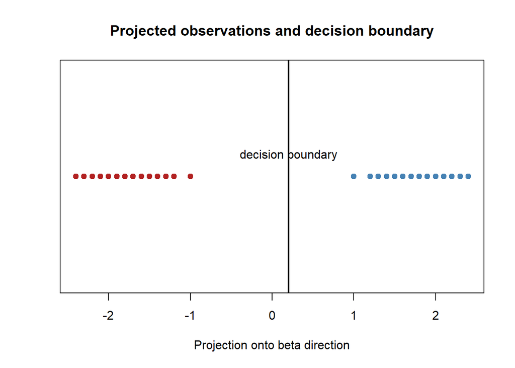

```r
plot(proj, rep(0, nrow(d2)),
     pch = 19,
     col = ifelse(d2$y == 1, "steelblue", "firebrick"),
     xlab = "Projection onto beta direction",
     ylab = "",
     yaxt = "n",
     main = "Projected observations and decision boundary")
abline(v = boundary, col = "black", lwd = 2)
text(boundary, 0.1, "decision boundary", pos = 3)
```

To normalize to the SVM form with the smallest functional margin equal to 1, we divide by the minimum value of $y_i f(x_i)$.

```r
min_yf <- min(d2$y * score)
min_yf
```

```
[1] 5
```

This minimum is 5, so:

$$\tilde{\beta} = \frac{\beta}{5} = (0.2, 0.4, -0.4, 0.8)^\top,
\qquad
\tilde{\beta}_0 = \frac{-1}{5} = -0.2.$$

Thus the normalized decision boundary is

$$\tilde{f}(x)= -0.2 + 0.2x_1 + 0.4x_2 - 0.4x_3 + 0.8x_4,$$

and the smallest value of $y_i\tilde{f}(x_i)$ is 1.

## Question 3: Peer review of a Homework 7 skill

The instructor’s GitHub account, **rqzhu-aide**, will open a **GitHub Issue** in the repository containing your Homework 7 submission. It will link to **one** assigned student’s repository.

1. **Use the skill.** Find the complete skill definition in the assigned student’s Homework 7 report. Copy it without changes into a local `SKILL.md` file in your own folder. You do not need to install it. Give your agent the path to the file and explicitly ask it to follow that skill while analyzing the `SAheart` data, using the response and predictor coding from Homework 7. Provide the necessary data information, but no additional preferences about methods, figures, model selection, or report style. Let the skill direct the analysis.

   Monitor the time, your token use, and your weekly quota while the agent works. If the run is taking too long or using your allowance too quickly, you may send a **steer message** asking the agent to finish immediately, or stop the run and summarize what you observed. A steer message redirects an agent while it is working; learn how to send one in your AI tool before starting.
2. **Write a peer review.** Read the student’s submitted report and what the skill produced in your run. Give a brief overall assessment, followed by **three major items the author could improve**. You may comment on any aspect of the skill or report. For each item, explain what you observed, why it matters, and what you recommend changing. If you stopped the run early, explain where and why. Write the review yourself, without AI assistance.
3. **Share your review.** Open a GitHub Issue in the assigned student’s Homework 7 repository containing your review. Copy the same review into your Homework 8 submission report and include a link to the GitHub Issue.

## Peer review for Question 3

### Overall assessment

This submission is strong and clearly follows the assigned skill. The author correctly identifies the response and predictors, codes `famhist` as required, and implements the full LDA/QDA comparison with a split, cross-validation, and held-out evaluation. The report also includes the required overall structure: a data/procedure paragraph, a figure, a table, and a compact interpretation. In particular, the candidate grid and the CV comparison are explained clearly, and the selected model is reported with its final test error. This is a well-executed submission.

### Major item 1: The one-page report should be even more concise and focused

What I observed: The report includes a lot of useful information, but some of the discussion and formatting are longer than necessary for a one-page report. The full skill appendix is also included, which is allowed as an appendix, but the one-page result could be tightened further.

Why it matters: The skill explicitly says the final report should be no longer than one printed page, with a figure, a table, and a brief summary. A tighter report makes the main conclusion easier to read and better highlights the key model choice.

Recommendation: Keep the main page to the essential results only, and move the full candidate table or more detailed model diagnostics to the appendix or companion materials instead of the main body.

### Major item 2: The model-selection logic could be stated even more explicitly

What I observed: The report does explain that the model was chosen using cross-validation, but the selection logic could be more direct. The reader would benefit from a clearer statement of why the selected model was preferred over the ordinary LDA and QDA baselines.

Why it matters: The skill emphasizes selecting the best valid candidate using training-only CV and then evaluating it once on the test set. Clear reporting is important because it shows the model choice was driven by validation evidence, not by the held-out test error.

Recommendation: Add a sentence such as: “The selected model was chosen because it minimized cross-validation misclassification rate among the valid candidates, with ordinary LDA and QDA included as baselines.” This would make the decision rule more transparent.

### Major item 3: The class-imbalance discussion could be more concrete

What I observed: The report mentions class imbalance and the difference between class 0 and class 1, but the interpretation could be stronger if it tied those issues more directly to the actual error pattern in the confusion matrix.

Why it matters: The class imbalance affects the interpretation of overall misclassification rate. A model can have a moderate overall error while still performing poorly on the minority class, so that limitation should be discussed clearly.

Recommendation: State explicitly that the overall error rate does not necessarily reflect equal performance across classes, and connect that point to the confusion matrix and the class counts in the final evaluation.

### GitHub Issue link

https://github.com/steven-jia-uiuc/stat432-fall2026/issues/4